# Lights, Camera, Ratings! What Makes Bollywood Movies a Hit

## Introduction

What makes a movie hit? Is it the exciting genre, the engaging storyline, or the presence of famous actors? In this blog post, we look at how a movie’s genre and the experience of its actors affect its IMDB ratings, hoping to uncover what audiences like best. Using two datasets related to Bollywood movies,one that covers genre, actors, director etc and another that focuses on ratings. We will explore ratings and actor details to find trends. Through this we aim to discover if certain genres generally get higher ratings and if famous actors make a difference in how a movie is rated.

## Data

I got the datasets from Github, The bollywood dataset is sourced from The Movie Database (TMDb), a trusted repository of movie-related information. TMDb provides comprehensive details about a variety of films, including Bollywood movies. Content: id: Unique identifier for each movie. title: Title of the Bollywood movie. year: Release year of the movie. rating: Audience rating based on TMDb votes. The IMDB_movies,@misc{yourusername/movie-dataset-2023, author = {Deven Bhagtani}, title = {IMDB Movie Dataset(2023-1951)}, year = {2023}, publisher = {GitHub}, journal = {GitHub repository}, howpublished = {}, }. Movie ID: Unique identifier for each movie Name: Title of the movie Year: Release year Genre: Categories or types of the movie Overview: Brief synopsis or plot summary Director: Name(s) of the director(s) Cast: Lead actors and actresses

## Results

How does the genre of a movie influence its IMDB rating?

To explore how the genre of a movie influences its IMDB rating, We began by cleaning the data and making it tidy. By performing some data wrangling. We created two new datasets that focused only on the relevant attributes. First, we separated out the main actor and primary genre from each movie in the IMDB_movies dataset. This allowed us to focus on the leading actor and the primary genre, which are likely to have the most significant influence on ratings. By filtering for movies released between 2000 and 2023, we concentrated on more recent data, which may be more relevant to current audience preferences. Next we joined this cleaned dataset (actor_data) with the Bollywood dataset (movie) by using an inner join on the movie_name. The inner join helped us combine the two datasets, keeping only the movies that appeared in both, which ensures we have matching records with genre, actor, and rating information. This merged dataset ‘movies’ provides us with a unified view of Bollywood movies that includes key information such as main genre, leading actor, release year, and IMDB rating. This cleaned data makes it easier to analyze how a movie’s genre affects its rating. It lets us compare ratings across different genres to see if some genres usually get higher ratings than others.

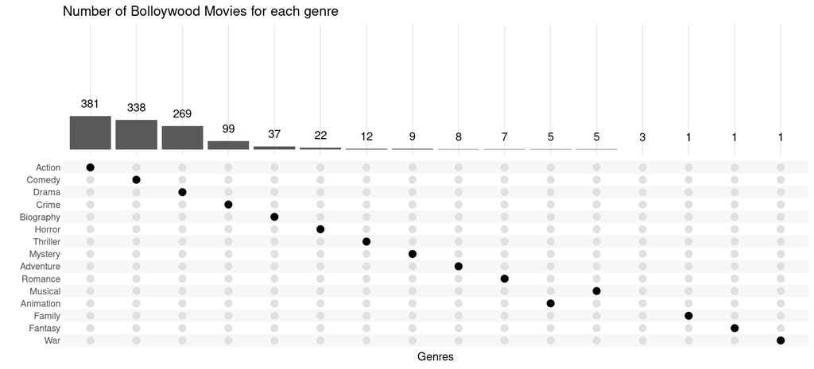

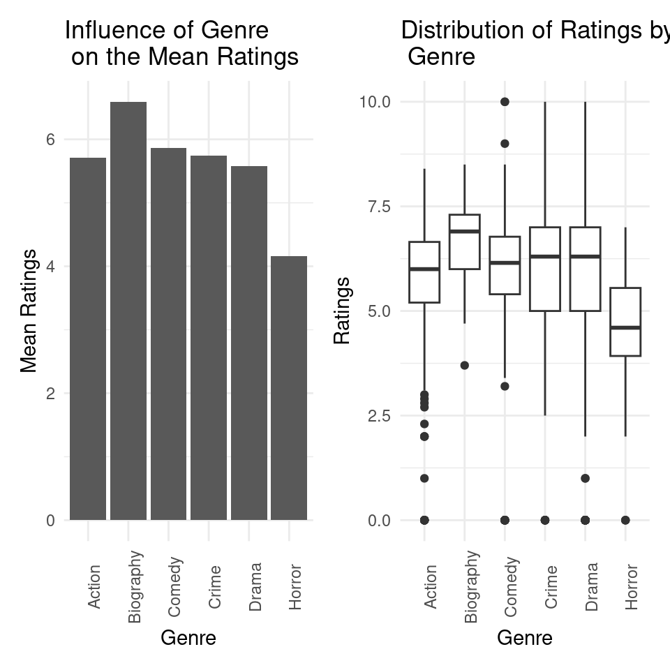

To answer how genre influences movie ratings, We first examined the number of movies for each genre to identify which genres were most common. Using a bar chart we visualized the count of Bollywood movies by genre, which revealed that genres like Action, Comedy, Drama, Crime, Biography, and Horror had the highest number of movies. We focused on these top six genres. Next we created two graphs for these selected genres. The first graph displays the average rating for each genre, helping to highlight which genres tend to receive higher ratings. This allows us to see if specific genres on average are rated higher by audiences. The second graph, a box plot, shows the distribution of ratings within each genre, giving us a clearer picture of the variability in ratings. It helps identify if some genres have a wider spread of ratings, which might indicate mixed audience reactions or if they are consistently rated in a certain range.From the results we found that genres like Biography tend to have higher average ratings, while genres like Horror generally receive lower ratings. This helped in understanding not just the average rating, but also how audience opinions vary within each genre.

Are established actors linked to higher movie ratings over the years?

To find out if established actors are linked to higher movie ratings over time, We defined “established actors” as those appearing in more than 20 movies. We started by selecting only the relevant columns like “Actor name”, “year”, and “movie_name” grouped by “Actor name” to count each actor’s total movie appearances, filtering to include only those with more than 20. Then we joined this list of established actors with the main “movies” dataset, creating a subset containing only movies featuring these frequent actors. To analyze rating trends we filtered this subset to include movies from 2018 to 2023 then calculated the average rating per year for each actor. This approach allows us to observe if movies with established actors tend to have higher ratings providing insight into the influence of actor popularity on ratings over recent years.

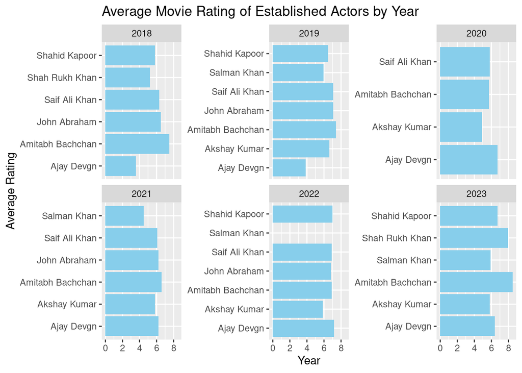

## Conclusion

In conclusion, this blog post gives us a better understanding of how movie genre and well known actors affect Bollywood movie ratings. We found that certain genres like Biography and Comedy tend to get higher ratings, while others like Horror usually receive lower ones. This shows that audiences may prefer some types of movies over others, which could influence how they rate them. When we looked at popular actors we saw that some like Amitabh Bachchan, consistently receive good ratings likely due to a strong fan following. Other actors have more ups and downs in their ratings which might depend on the specific movies they release each year.Overall, this blog shows that both the genre and the popularity of actors can impact a movie’s ratings. For film-makers, understanding these patterns can help them make choices that better connect with audiences. As Bollywood changes keeping track of these trends can guide the industry in creating movies that audiences enjoy.